# BSTFA Package

Abstract

The BSTFA package for R is a tool for fitting fully Bayesian spatio-temporal factor analysis models with a normal likelihood. The package implements a computationally rapid approach using dimension reduction via basis functions. The package also supports a non-reduced spatio-temporal factor analysis model, albeit with much slower computation. Also included are functions to predict and plot the response variable at missing/observed locations, methods to visualize processes (such as the linear trend through time) on a grid or map, and a function to plot estimated behavior through some given timeframe (such as annual seasonal behavior).

# Intended Audience

This document is intended to help even novice statistics students implement a fully Bayesian spatio-temporal analysis. Every function within the package is designed with this audience in mind. This document is meant to guide any potential user of this package through the basic theory and implementation of our models: in essence, it is an instruction manual. The bulk of this document contains examples of our functions applied on a real data set.

The outline is as follows. First, we introduce the motivation behind our Bayesian spatio-temporal factor analysis models and why simplifying the model for fast computation is important. Section 1 outlines the available functions and procedures within the `BSTFA` package along with demonstrations on a real data set. Some basic theory and methodology are contained in Section 2, and Section 3 details specific features of the package. The appendix contains references and additional notes on computation.

# Motivation

Consider for example the motivating data for the `BSTFA` package: a collection of temperature measurements across the state of Utah. The data were collected from May 1912 through January 2015 from 146 weather stations across the state. These measurements are 30-day averages of daily minimum observed temperatures in degrees Celcius, with each location’s measurements zero-centered. This environmental process exhibits some of the challenges common in environmental modeling; that is, the data show obvious spatial and temporal dependence and not all contributing agents are known or easy to include in a modeling scheme.

Take for example the observations for three weather stations: Moab, Canyonlands National Park, and Logan. The Moab and Canyonlands stations are near one another (within 50 miles) while the Logan station is far away (300 miles). Figure 1 shows these same temperature series zoomed in on the years 1999 through 2001. The difference between low temperatures in winter 2000 and winter 2001 is slight in Moab and the Canyonlands, but in Logan, the low temperature decreases dramatically from winter 2000 to winter 2001, showing that locations near each other in space exhibit similar environmental trends. We don’t know from the data alone what contributed to that difference; we simply know it exists. We need a model that provides inference into the spatio-temporal relationships. Spatio-temporal factor analysis allows us to account for underlying spatio-temporal dependencies and explore numerical and visual summaries of that dependence.

A fully parameterized Bayesian approach to spatio-temporal factor analysis is computationally burdensome. Our `BSTFA` package accounts for this by using dimension reduction via basis functions, allowing for faster computation. The remainder of this vignette describes the `BSTFA` package and its use of basis functions, as well as all implemented methods for plotting, prediction, and inference.

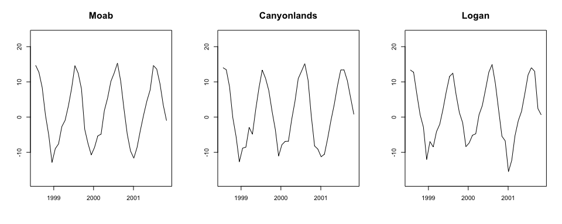

Mean-centered 30-day average daily minimum temperatures for 3 Utah weather stations (Moab, left; Canyonlands, middle; Logan, right) from 1999 to 2001.

# 1 What is Implemented?

The `BSTFA` package contains implementation of two versions of a spatio-temporal factor analysis model along with functions for prediction, plotting and visualizing posterior surfaces. The model-fitting functions are defined in Section 1.1, while the methodology associated with these models is described more fully in Section 2. The `BSTFA` package’s prediction methods are discussed in Section 1.2, functions for plotting/visualization are described in Section 1.3, and notes about computational speed are outlined in Section 1.4.

While each of these sections describes some arguments to the functions, the best way to understand all available function arguments is to look at the R help documentation.

## 1.1 Model-fitting Functions

The `BSTFA` package contains two model fitting functions: `BSTFA`, the smoother and computationally-efficient spatio-temporal factor analysis model using basis functions for the factor analysis; and `BSTFAfull`, the fine-grain but slower spatio-temporal factor analysis model using Gaussian processes for the factor analysis. Both functions return a $\textit{list}$ object containing all information required to summarize posterior inference, including all posterior draws from each parameter, matrices containing the basis functions, and information about computation time. Each function has only three required arguments, summarized in Table 1.1. Other arguments relating to model fitting and prior specification will be discussed more fully in Section 2.

*Table 1.1: This table summarizes required arguments for the `BSTFA` and `BSTFAfull` functions.*

[output not shown]

The `BSTFA` and `BSTFAfull` functions are demonstrated below. Additional MCMC arguments such as `iters`, `thin`, and `burn` have default values, but they can be specified as in any Bayesian model to control the number of posterior samples. The `verbose` argument controls whether or not the function prints status updates during sampling. Although the default value for this is `TRUE`, for the sake of this vignette, `verbose` will always be set to `FALSE`. Also, if desired, the function can save output directly to a `.Rdata` file by setting `save.output == TRUE`. This value is set to `FALSE` by default.

The `utahDataList` list object in the `BSTFA` package contains the observed temperature data (`TemperatureVals`), the corresponding dates (`Dates`), the coordinates (`Coords`), and the weather station names (`Locations`).

```r
bstfa.output = BSTFA(ymat=utahDataList$TemperatureVals,
                     dates=utahDataList$Dates,
                     coords=utahDataList$Coords,
                     verbose=FALSE)
```

```r
bstfa_full.output = BSTFAfull(ymat=utahDataList$TemperatureVals,
                         dates=utahDataList$Dates,
                         coords=utahDataList$Coords,
                         verbose=FALSE)
```

### 1.1.1 Understanding Output

The `BSTFA` and `BSTFAfull` functions output a list object. It should be noted that a user can use all functions within the `BSTFA` package without understanding or using the specific output. We provide these additional details for more in-depth analyses and summaries. Most objects contained in the list are self-explanatory. A few, however, warrant further explanation.

- Each object that is a parameter (i.e., `beta`) is an MCMC object from the `coda` package (Plummer et al., 2006) with number of rows equal to the number of MCMC draws.
- `time.data` is a matrix with number of rows equal to `iters` and columns indicating the computation time (in seconds) for the given parameter on that given iteration. This is the object used to create the `compute_summary` mentioned in Section 1.4.
- `y.missing` is a matrix with number of rows equal to the number of missing data points in `ymat` and number of columns equal to the number of MCMC draws. These are posterior draws from relevant distributions of the missing values of `ymat`. If `save.missing=FALSE` in the function, this will be `NULL`.
- `model.matrices` stores all basis function matrices and other useful matrices for calculating $Y$ (more details given in Section 2).
  - `newS` is equivalent to $\mathbf{B_\beta} \equiv \mathbf{B}_{\xi_j} \forall j$ and has dimension $n \times b_\beta$. Note that $b_\beta = b_\xi$, and this value is `n.spatial.bases` in the model functions.
  - `linear.Tsub` is $t-\bar{t}$, a $T \times 1$ vector of values $t-\bar{t}$ $\forall$ $t$.
  - `seasonal.bs.basis` is the $t \times u$ matrix of cubic circular b-spline bases where each row represents $\mathbf{U}(t^*)$ for a given time point $t^*$.
  - `confoundingPmat.prime` is an orthogonal projection matrix $P^{\perp}$ used to prevent confounding between the linear and seasonal components and the factor analysis component. For more information about this component, see Berrett et al. (2020).
  - `QT` is the $T \times R_t$ matrix of Fourier basis functions for the factors.
  - `QS` is the $n \times R_s$ matrix of basis functions used for the loadings. If `spatial.style == load.style` and `n.spatial.bases == n.load.bases`, this will be equivalent to `newS`.
- $\mathbf{Note:}$ Care must be taken in understanding the ordering of `F.tilde` and `Lambda.tilde` (discussed in greater detail in Section 2.1.3). Each draw of `F.tilde` (meaning, each column) has dimension $TL \times 1$. This means the first $T$ values correspond to factor one, the next $T$ values correspond to factor two, and so on. However, each draw of `Lambda.tilde` has dimension $Ln \times 1$. This means the first $L$ values correspond to location one, the next $L$ values correspond to location two, and so on. When converting a draw of `F.tilde` into a matrix, setting `byrow=FALSE` provides the appropriate $T \times L$ matrix, while when converting a draw of `Lambda.tilde` into a matrix, setting `byrow=TRUE` provides the appropriate $n \times L$ matrix.

## 1.2 Prediction

The function `predictBSTFA` takes as its first argument the output from the `BSTFA` or `BSTFAfull` functions. Within the function, posterior samples from relevant parameters are used to generate predictions either for the spatio-temporal processes, $Y(\mathbf{s}, t)$, at observed location $\mathbf{s}$ and time $t$, or for, $Y(\mathbf{s^*}, t)$, at $\textit{unobserved}$ location $\mathbf{s^*}$ and time $t$. The `location` argument takes either a location number (corresponding to the appropriate column of your `ymat` argument) for predicting at an observed location, or a matrix/data frame of coordinate values if predicting at a new location.

If the argument `type` is set to `"all"`, the function will return draws of $Y(\mathbf{s}, t) \text{ } \forall \text{ } (\mathbf{s},t)$. `type` can also be set to `"mean"`, `"median"`, `"ub"` (upper bound), or `"lb"` (lower bound). The option `pred.int` controls whether the calculated uncertainty is a prediction interval (`pred.int == TRUE`; default value) or a credible interval (`pred.int == FALSE`).

The code below predicts at an observed location, “Alpine, Utah”. Since `type == "all"`, the function will return a $t \times d$ MCMC object matrix of posterior draws of $Y(\mathbf{s}, t) \text{ } \forall \text{ } t$ with $d$ being the number of MCMC draws. Each column represents one draw of the $T \times 1$ vector, $\mathbf{Y}$.

```r
loc = 1 # Alpine, Utah in our data set
preds = predictBSTFA(bstfa.output,
                     location = loc,
                     type='all',
                     pred.int=TRUE,
                     ci.level=c(0.025,0.975))
dim(preds)
```

```
#> [1] 1251  495
```

The code below sets `type == "mean"` and returns a $t \times 1$ MCMC object vector containing the posterior $\textit{mean}$ of $Y(\mathbf{s}, t) \text{ } \forall \text{ } t$.

```r
loc = 1 # Alpine, Utah in our data set
preds = predictBSTFA(bstfa.output,
                     location = loc,
                     type='mean',
                     pred.int=TRUE,
                     ci.level=c(0.025,0.975))
dim(preds)
```

```r
length(preds)
```

```
#> [1] 1251
```

The code below predicts at an $\textit{unobserved}$ location by setting the `location` argument to a data frame of coordinate values. In this case, we predict to a city without a monitor, Torrey, Utah, with longitude 111.41$^\circ$ W and latitude 38.29$^\circ$ N.

```r
loc = data.frame('Longitude' = 111.41, 'Latitude' = 38.29) # Torrey, Utah
preds_new = predictBSTFA(bstfa.output,
                         location = loc,
                         type='all',
                         pred.int=TRUE,
                         ci.level=c(0.025,0.975))
```

The `predictBSTFA` function is also called within the `plot_location` function, which takes similar arguments as `predictBSTFA` with the addition of a few extra plotting arguments. `xrange` defines the time points $t \in T$ at which the estimates are plotted, with default value `NULL` indicating to plot on all of $T$. `truth` (default value `FALSE`) will plot the observed data along with the estimates if the `location` comes from the data set. `uncertainty` (default value `TRUE`) indicates whether to plot a prediction interval (`pred.int==TRUE`) or a credible interval (`pred.int==FALSE`) with the estimate.

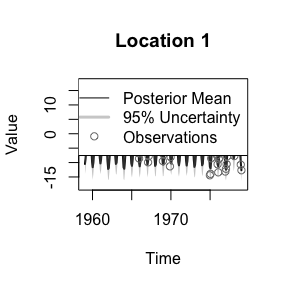

```r
loc = 1 # Alpine, Utah in our data set
plot_location(bstfa.output,
              location=loc,
              type='mean',
              pred.int=TRUE,
              uncertainty=TRUE,
              ci.level=c(0.025,0.975),
              xrange=c('1959-01-01', '1979-01-01'),
              truth=TRUE)
```

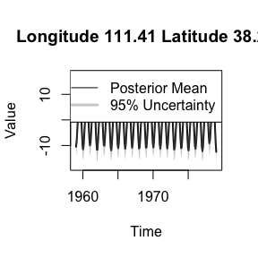

```r
loc = data.frame('Longitude' = 111.41, 'Latitude' = 38.29) # Torrey, Utah
plot_location(bstfa.output,
              location=loc,
              type='mean',
              pred.int=TRUE,
              uncertainty=TRUE,
              ci.level=c(0.025,0.975),
              xrange=c('1959-01-01', '1979-01-01'),
              truth=FALSE)
```

## 1.3 Plotting/Visualization

The `BSTFA` package contains multiple functions for plotting and visualizing the model output. Of course, all of these can be implemented on your own (the output from the `BSTFA` or `BSTFAfull` functions contain all posterior draws and basis function matrices), but these functions exist for quick plotting and visualization of posterior distributions. Some functions use base R for plotting while others use the `ggplot2` package. Table 1.2 below displays a table with each plotting function and a basic description.

*Table 1.2: Plotting/visualization functions in the `BSTFA` package.*

[output not shown]

For instance, `plot_annual` can plot the estimated annual seasonal trend at any (observed or unobserved) location. The code for doing this for the observed location, Alpine, Utah, is provided below, along with the corresponding plot, where the black line is the average and the gray band is the 95% credible interval for the average, and the gray dots are the observations plotted on their day of year. This shows the expected seasonal behavior - that the temperatures tend to increase in the spring/summer months and decrease in the fall/winter months.

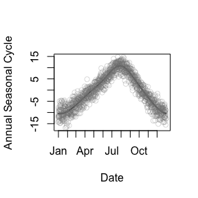

```r
plot_annual(bstfa.output,
            location=1,
            years='one')
```

The `plot_spatial_param` function can plot the estimated linear slope or factor loadings at all observed locations. The `type` argument (default is `"mean"`, with other options `"median"`, `"ub"`, or `"lb"`) indicates which summary to show. The `parameter` argument can be set either to `"slope"` or `"loading"`. If set to `"slope"`, the argument `yearscale` (default is `TRUE`) controls whether the slope estimates are “per year”. If set to `"loading"`, the `loadings` argument indicates which loading to plot. First, we provide an example to plot the estimated linear change in temperature (increase or decrease) across time. The color of the resulting plot shows the long-term increasing (positive and red) or decreasing (negative and blue) behavior over the observed time period for the observed locations. Notice that most locations show an average increase in temperature of between 0 and 0.025 degrees Celcius per year.

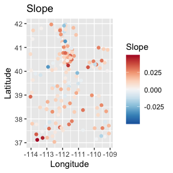

```r
plot_spatial_param(bstfa.output,
          type='mean',
          parameter='slope',
          yearscale=TRUE)
```

Next, we provide example code for plotting a particular loading, in this case, the loadings for the first factor. The resulting plot shows the weights that each location places on the first factor, with the color indicating the strength of the weight (darker colors indicate a stronger weight). The big red dot shows the location of the fixed factor; in this case, the first factor, fixed at Wendover, Utah.

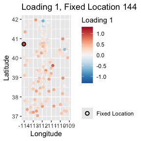

```r
plot_spatial_param(bstfa.output,
          type='mean',
          parameter='loading',
          loadings=1)
```

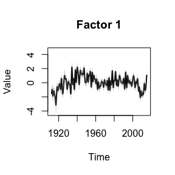

```r
plot_factor(bstfa.output,
            together=FALSE,
            include.legend=FALSE,
            factor=1,
            type='mean')
```

To plot the factors together, set `together==TRUE`, as in the example code below. This figure provides a plot of all four estimated factors, or common behaviors of the temperature measurements across time that weren’t explicitly modeled (in contrast to the linear increasing/decreasing and seasonal behaviors that were explicitly modeled). Notice that Factor 1 is higher in the 1940’s than the other factors, indicating that locations who load heavily on this first factor tend to have higher temperatures in the 1940s than the other locations.

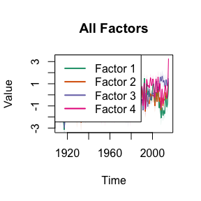

```r
plot_factor(bstfa.output,
            together=TRUE,
            include.legend=TRUE,
            type='mean')
```

```
#> replace the existing one.
```

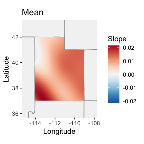

```r
map_spatial_param(bstfa.output,
         parameter='slope',
         yearscale=TRUE,
         type='mean',
         map=TRUE,
         state=TRUE,
         location='utah',
         fine=100)
```

## 1.4 Speed

As mentioned before, the `BSTFA` package takes advantage of various mathematical and coding shortcuts to speed up computation. Specifically, the package uses sparse matrices, the vec operator, and basis functions to improve speed. The sparse matrices are implemented using the `Matrix` package. The basis functions reduce the number of parameters, thus reducing needed computation. In this section, we illustrate computational improvement over the “full” model for various numbers of bases.

The model details are covered in greater detail in Section 2, so here we supply a short description as to why `BSTFA` is much faster than `BSTFAfull`. Each function models the factor analysis portion differently. In `BSTFAfull`, we model the factors using a vector autoregressive approach and the factor loadings with an exponential spatial dependence structure as in Berrett et al. (2020). This causes three main computational issues:

- The autoregressive step requires looping through all time points, with each point requiring matrix inversion and multiplication. This process can be sped up by making use of C++ within R, but even that takes too long in an MCMC algorithm when $T$ gets remotely large (around 100 time points).
- Estimating the exponential spatial dependence structure for the loadings requires inversion of large, sometimes dense matrices (of size $n \times n$) in every iteration of the algorithm.
- Estimating certain parameters in this framework requires the Metropolis-Hastings algorithm which introduces increased computation time and potential inefficiency (e.g., smaller effective posterior sample sizes).

The `BSTFA` function instead fits both the factors and the factor loadings using basis functions of various forms, as discussed in Section 2. This solves the problems mentioned above by:

- Removing the need for a vector autoregressive loop.
- Lowering the dimension of the previously large matrices.
- Introducing conjugacy. The entire model used in the `BSTFA` function is conditionally conjugate, allowing for an efficient Gibbs sampler without needing to use any Metropolis steps.

For reference, Table 1.3 below compares the number of seconds per MCMC iteration for the `BSTFA` and `BSTFAfull` functions on simulated data with differing numbers of locations (first column) and bases (indicated by the different columns) for the factor loadings. In each instance, $T = 300$ and the number of temporal bases is $R_t = 60$. The computations were carried out on a MacBook Pro (13-inch, 2022) with an Apple M2 chip (8-core CPU, 3.5 GHz) and 8 GB of RAM, running macOS 15.1.1.

*Table 1.3: Computation time in seconds per MCMC iteration for the `BSTFA` and `BSTFAfull` functions.*

| $n$ | `BSTFA`, 8 loading bases | `BSTFA`, 20 loading bases | `BSTFA`, 50 loading bases | `BSTFAfull` |
| --- | --- | --- | --- | --- |
| 100 | 0.016 | 0.017 | 0.021 | 0.481 |
| 200 | 0.029 | 0.031 | 0.036 | 1.292 |
| 300 | 0.051 | 0.05 | 0.056 | 1.693 |
| 400 | 0.082 | 0.078 | 0.086 | 2.7 |
| 500 | 0.12 | 0.119 | 0.126 | 4.186 |

The plots below illustrate that there is a tradeoff between computation speed and smoothness; that is, computation time is dramatically reduced at the cost of over-smoothing. The `BSTFAfull` returns fine-grain estimates with a high computational burden, while `BSTFA` provides a smooth representation of the process in a fraction of the time. The first row of plots compares the grid of estimates for the third loading from both the `BSTFAfull` (left) and `BSTFA` functions with 8 (center) and 6 (right) spatial bases on the loadings. The loading plot for `BSTFAfull` was fit with `fine=50` to save on computation time while the two `BSTFA` loading plots were fit with `fine=100`. The second set of plots compares the factor estimates from `BSTFAfull` (left) and `BSTFA` with 200 (center) and 126 (right) temporal bases on the factors. The estimates computed by `BSTFAfull` and `BSTFA` display similar patterns, but the computationally efficient `BSTFA` estimates are smoother spatially and temporally.

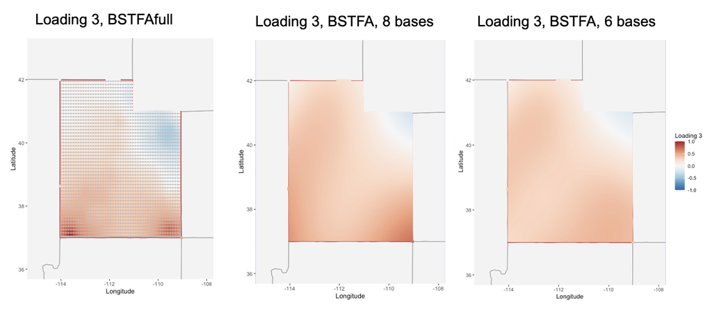

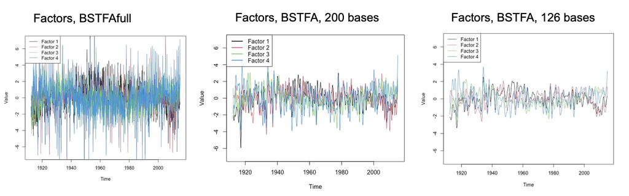

The `BSTFA` package contains a function `compute_summary` that takes as an argument the object from `BSTFA` or `BSTFAfull` and prints a detailed summary of computation time.

```r
compute_summary(bstfa.output)
```

```
#> [1] "Setup Time: 1.411 seconds."
#> [1] "PARAMETERS"
#> [1] "Beta: 0.003 seconds per iter."
#> [1] "Xi: 0.263 seconds per iter."
#> [1] "F: 0.073 seconds per iter."
#> [1] "Lambda: 0.054 seconds per iter."
#> [1] "Sigma2: 0.00191 seconds per iter."
#> [1] "OVERALL PER ITERATION"
#> [1] "Pre-Factor Analysis: 0.264 seconds."
#> [1] "Post-Factor Analysis: 0.394 seconds."
#> [1] "TOTAL TIME"
#> [1] "Total time: 394.992 seconds (6.583 minutes) for 1000 iterations."
```

# 2 Methodology

This section details the methodology implemented in the `BSTFA` package. Specifically, the processes included in the model, basis function dimension reduction techniques, and details about spatio-temporal factor analysis are all discussed. For further details, the reader will be directed to appropriate references, including the original paper to implement the model contained in the `BSTFAfull` function.

## 2.1 Model

The `BSTFA` package implements a Bayesian spatio-temporal factor analysis regression model. Our model follows the structure proposed by Berrett et al. (2020); namely, for a location $\mathbf{s} \in D$ and a time index $t \in T$, let $Y(\mathbf{s}, t)$ be the mean-centered response variable such that
$$Y(\mathbf{s}, t) = (t - \bar{t})\beta(\mathbf{s}) +
g(\mathbf{\xi}(\mathbf{s}), t) +
\mathbf{f}'(t)\mathbf{\lambda}(\mathbf{s}) + \epsilon(\mathbf{s}, t)$$
where $t-\bar{t}$ represents the time $t$ centered by average time over the period of interest, $\beta(\mathbf{s})$ represents a spatially dependent linear slope in time, $g(\mathbf{\xi}(\mathbf{s}), t)$ represents a spatially dependent seasonal periodic process, $\mathbf{f}'(t)\mathbf{\lambda}(\mathbf{s})$ is a spatio-temporal confirmatory factor analysis (CFA) process, and $\epsilon(\mathbf{s}, t)$ is a zero-mean independent Gaussian residual process with variance $\sigma^2$.

The approach described in Berrett et al. (2020) is implemented in the `BSTFAfull` function. However, as discussed before, the `BSTFA` function makes adjustments to the factor analysis component $\mathbf{f}'(t)\mathbf{\lambda}(\mathbf{s})$ for increased computational speed. We provide a brief overview of the model for each interpretable process here, but for details, we refer the reader to Berrett et al. (2020).

### 2.1.1 Linear Component

The linear changes across time, $\beta(\mathbf{s})$, are allowed to vary spatially by using spatial basis functions. Let $\boldsymbol{\beta} = (\beta(\mathbf{s}_1), \dots, \beta(\mathbf{s}_n))'$ be the $n \times 1$ vector of coefficients for the locations of interest. We model
$$\boldsymbol{\beta} \sim N(\mathbf{B_\beta} \boldsymbol{\alpha_\beta},
\tau^2_\beta \mathbf{I}),$$
where $\mathbf{B_\beta}$ is an $n \times b_\beta$ matrix of basis functions, $\boldsymbol{\alpha}_\beta$ represents the corresponding $b_\beta \times 1$ vector of coefficients, $\tau^2_\beta$ represents the variances, and $\mathbf{I}$ the appropriate identity matrix. We place conjugate priors on $\boldsymbol{\alpha}_\beta$,

$$\boldsymbol{\alpha}_\beta \sim N(0, \mathbf{A}^{-1}) \\$$
where $\mathbf{A}$ is a diagonal precision matrix, and $\tau^2_\beta$,

$$\frac{1}{\tau^2_\beta} \sim Gamma(\gamma, \phi),$$

where $\phi$ is the rate parameter of the Gamma distribution. Table 2.1 provides a list of the arguments to the `BSTFA` and `BSTFAfull` functions that are associated with the linear component.

*Table 2.1: Arguments to `BSTFA` and `BSTFAfull` associated with the linear component.*

| Argument | Default Value | Description |
| --- | --- | --- |
| `linear` | `TRUE` | TRUE/FALSE value indicating whether the linear component is included in the model. |
| `beta` | `NULL` | Vector of starting values for $\boldsymbol{\beta}$ of length $n \times 1$; if none is supplied, realistic starting values are calculated. |
| `alpha.prec` | `1e-5` | Value on the diagonal of the precision matrix $\mathbf{A}$. |
| `tau2.gamma` | `2` | Value of the shape parameter, $\gamma$, for the prior of the variance, $\tau^2_\beta$. |
| `tau2.phi` | `1e-6` | Value of the rate parameter, $\phi$, for the prior of the variance, $\tau^2_\beta$. |

### 2.1.2 Seasonal Component

Similarly, the spatially dependent seasonal periodic process also uses basis functions. First, we use cubic circular b-splines (Wood, 2017) in time on the day of the year to model the periodic seasonal component. Let

$$g(\boldsymbol{\xi}(\mathbf{s}), t) = \mathbf{U}(t^*)
\boldsymbol{\xi}(\mathbf{s}),$$

where $\mathbf{U}(t^*)$ is the $u \times 1$ vector of cubic circular b-splines evaluated at the day of year of time $t$, denoted by $t^*$, and $\boldsymbol{\xi}(\mathbf{s})$ the corresponding $u \times 1$ vector of coefficients. We then model the coefficients using the same approach used for the linear slopes. Namely, let $\boldsymbol{\xi}_j = (\boldsymbol{\xi}_j(\mathbf{s}_1), \dots, \boldsymbol{\xi}_j(\mathbf{s}_n))'$ represent the coefficients for the $j$th spline for all locations of interest. Then,
$$\boldsymbol{\xi}_j \sim N(\mathbf{B}_{\xi_j}
\boldsymbol{\alpha}_{\xi_j}, \tau^2_{\xi_j} \mathbf{I}),$$
where $\mathbf{B}_{\xi_j}$ is an $n \times b_{\xi_j}$ matrix of basis functions, $\boldsymbol{\alpha}_{\xi_j}$ represents the corresponding $b_{\xi_j} \times 1$ vector of coefficients, $\tau^2_{\xi_j}$ represents the variances, and $\mathbf{I}$ the appropriate identity matrix. Each $\boldsymbol{\alpha}_{\xi_j}$ and $\tau^2_{\xi_j}$ are modeled with the same prior distributions (and same hyperparameters) as $\boldsymbol{\alpha}_\beta$ and $\tau^2_\beta$. Table 2.2 provides a list of the arguments to the `BSTFA` and `BSTFAfull` functions that are associated with the seasonal component.

*Table 2.2: Arguments to `BSTFA` and `BSTFAfull` associated with the seasonal component.*

| Argument | Default Value | Description |
| --- | --- | --- |
| `seasonal` | `TRUE` | TRUE/FALSE value indicating whether the seasonal component is included in the model. |
| `xi` | `NULL` | Vector of starting values for $\boldsymbol{\xi}$ of length $un \times 1$; if none is supplied, realistic starting values are calculated. |
| `n.seasn.knots` | `7` | Value representing the value of $u$ (the number of circular B-spline knots). |

### 2.1.3 Factor Analysis Component

`BSTFAfull` uses a vector autoregressive model on the factors and an exponential Gaussian process model on the loadings. This is quite computationally expensive. The `BSTFA` function reduces this computational burden and is discussed in Section 2.3.

If $L$ represents the number of factors, we point out that $\mathbf{f}(t)$ is an $L \times 1$ vector of factors (a.k.a. scores) at time $t$ and $\boldsymbol{\lambda}(\mathbf{s})$ is an $L \times 1$ vector of loadings for each factor at location $\mathbf{s}$. Define $\mathbf{F} = [\mathbf{f}(1)\, \cdots \,\mathbf{f}(T)]'$ to be the $T \times L$ matrix for all $L$ factors and $T$ times of interest and $\mathbf{\Lambda} = [\boldsymbol{\lambda}(\mathbf{s}_1)\, \cdots \, \boldsymbol{\lambda}(\mathbf{s}_n)]$ to be the $L \times n$ loading matrix for all $n$ locations of interest. As required for identifiability by CFA, given $L$ number of factors, we fix the values for the loadings for $L$ locations with an $L$-rank matrix of constants (Rencher & Christensen, 2012). Table 2.3 provides a list of the arguments to the `BSTFA` and `BSTFAfull` functions that are associated with the factor analysis component.

*Table 2.3: Arguments to `BSTFA` and `BSTFAfull` associated with the factor analysis component.*

[output not shown]

### 2.1.4 Residual Error

The variance of the zero-mean independent Gaussian residual process, $\sigma^2$, is modeled with a conjugate prior similar to the other variance components,
$$\frac{1}{\sigma^2} \sim Gamma(\gamma_\sigma, \phi_\sigma),$$
where $\phi_\sigma$ is the rate parameter of the Gamma distribution. Table 2.4 provides a list of the arguments to the `BSTFA` and `BSTFAfull` functions that are associated with the residual variance.

*Table 2.4: Arguments to `BSTFA` and `BSTFAfull` associated with the Gaussian residual process.*

| Argument | Default Value | Description |
| --- | --- | --- |
| `sig2` | `NULL` | A starting value for $\sigma^2$; if none is supplied, the starting value will be the variance of the non-missing values of `ymat`. |
| `sig2.gamma` | `2` | Value of the shape parameter, $\gamma_\sigma$, for the prior of the overall residual variance, $\sigma^2$. |
| `sig2.phi` | `1e-5` | Value of the rate parameter, $\phi_\sigma$, for the prior of the overall residual variance, $\sigma^2$. |

## 2.2 Basis Functions

Basis functions are a projection of a process onto a set of linear combinations of lower-dimension functions (Cressie et al., 2022). We make use of basis functions to allow for smooth estimates for each process across space and to drastically increase computational speed. For spatial modeling, the `BSTFA` package has three basis function forms built in: Fourier bases, bisquare bases, and thin-plate spline bases. For temporal modeling, only Fourier bases are implemented. Because the Fourier basis function is the default for the `BSTFA` package, that is the only methodology discussed in detail here; for the others, we refer the reader to Cressie & Johannesson (2008) for bisquare bases and Nychka (2000) for thin-plate spline bases.

We use Fourier bases because of their connection to Gaussian processes and their computational flexibility. A Gaussian process can be approximated quite well with orthogonal spectral basis functions (Wikle, 2002). One example is to use some number of principal components of the spatial covariance matrix. These spectral basis functions can themselves be represented as a sum of sine and cosine functions (Paciorek, 2007) reminiscent of a trigonometric Fourier series. Fourier bases, then, can capture the frequencies exhibited in the principal components of the underlying Gaussian process, granting a smooth approximation of the process.

We make use of Fourier basis functions for both spatial and temporal dependence. First, consider the Fourier bases for temporal dependence. Let $QT_r(t)$ and $QT_{r+1}(t)$ be the $r^{\text{th}}$ and $(r+1)^{\text{th}}$ columns of the matrix of bases for time $t$ for $r = 1, 3, 5, \dots R_t$. Then,

$$QT_r(t) = \sin\left(2\pi \frac{r+1}{2} \frac{t}{f_t}\right)$$
$$QT_{r+1}(t) = \cos\left(2\pi \frac{r+1}{2} \frac{t}{f_t}\right),$$
where $f_t$ is the frequency of the Fourier function.

For the spatial basis functions, we must accommodate the two-dimensional nature of space. Thus, we multiply the sine and cosine functions for each dimension (Paciorek, 2007). Let $QS_r(\mathbf{s})$ and $QS_{r+1}(\mathbf{s})$ be the $r^{\text{th}}$ and $(r+1)^{\text{th}}$ columns of the matrix of bases evaluated at location $\mathbf{s}$ for $r = 1, 3, 5, \dots R_s$. Then,

$$QS_r(\mathbf{s}) = \sin\left(2\pi \frac{r+1}{2}
\frac{\mathbf{s}_{[1]}}{f_{\mathbf{s}_{[1]}}}\right) * \sin\left(2\pi
\frac{r+1}{2} \frac{\mathbf{s}_{[2]}}{f_{\mathbf{s}_{[2]}}}\right)$$
$$QS_{r+1}(\mathbf{s}) = \cos\left(2\pi \frac{r+1}{2}
\frac{\mathbf{s}_{[1]}}{f_{\mathbf{s}_{[1]}}}\right) * \cos\left(2\pi
\frac{r+1}{2} \frac{\mathbf{s}_{[2]}}{f_{\mathbf{s}_{[2]}}}\right)$$
where $\mathbf{s}_{[1]}$ represents the first coordinate of $\mathbf{s}$ (e.g., longitude), and $\mathbf{s}_{[2]}$ the second coordinate (e.g., latitude), and $f_{\mathbf{s}_{[1]}}$ and $f_{\mathbf{s}_{[2]}}$ are the corresponding frequencies of the Fourier functions.

The `BSTFA` package contains a helper function to visualize spatial Fourier bases over a given set of coordinates. This can be useful when trying to decide frequencies (`freq.lon` and `freq.lat`) and number of bases (`R_s`) to fit in your model. This function is demonstrated below using the Utah temperature data.

[figure not shown]

```r
plot_fourier_bases(utahDataList$Coords,
                   R=6,
                   plot.3d=TRUE,
                   freq.lon = diff(range(utahDataList$Coords[,1]))^2,
                   freq.lat = diff(range(utahDataList$Coords[,2]))^2)
```

## 2.3 Spatio-temporal Factor Analysis using Basis Functions

We model the factors and loadings using the bases in the following way. Let $\mathbf{\tilde{F}} = \mbox{vec}(\mathbf{F})$, be the vectorized $TL\times1$ vector of all factors, and $\mathbf{\tilde{\Lambda}} = \mbox{vec}(\mathbf{\Lambda})$ be the vectorized $Ln \times 1$ vector of all loadings. We model $\mathbf{\tilde{F}}$ and $\mathbf{\tilde{\Lambda}}$ using a similar basis function decomposition used for the coefficients of the other processes described in 2.1.1 and 2.1.2; namely,
$$\mathbf{\tilde{F}} = (\mathbf{I}_L \otimes
\mathbf{QT})\mathbf{\alpha}_F$$
$$\mathbf{\tilde{\Lambda}} \sim N\left(( \mathbf{QS} \otimes
\mathbf{I}_L)\mathbf{\alpha}_{\Lambda}, \tau_{\Lambda}^2 \mathbf{I}_{Ln}
\right)$$
where $\mathbf{QT}$ is a $T \times (R_t+1)$ matrix of temporal bases, $\mathbf{QS}$ is a $n \times (R_s+1)$ matrix of spatial bases, $\mathbf{I}_L$ is the $L\times L$ identity matrix, $\mathbf{\alpha}_F$ is an $(R_t+1)L\times 1$ vector of coefficients, $\mathbf{\alpha}_\Lambda$ is an $L(R_s+1)\times 1$ vector of coefficients, and $\tau_{\Lambda}^2$ is the error variance for the loadings.

Both sets of coefficients are modeled in the same way as $\mathbf{\alpha}_\beta$ and $\mathbf{\alpha}_{\xi_j}$,
$$\mathbf{\alpha}_F \sim N(\mathbf{0}, \mathbf{A}_{\alpha_{F}}^{-1})$$
$$\mathbf{\alpha}_\Lambda \sim N(\mathbf{0},
\mathbf{A}_{\alpha_{\Lambda}}^{-1}),$$
and the variance component for the loadings $\tau_{\Lambda}^2$ the same as $\tau_{\beta}^2$ and $\tau_{\xi_j}^2$,
$$\frac{1}{\tau_{\Lambda}^2} \sim Gamma(\gamma, \phi).$$
Once again, the hyperparameters for the variance take the same argument values as used in the linear and seasonal components. Table 2.5 provides a list of the arguments to the `BSTFA` and `BSTFAfull` functions that are associated the with basis functions.

*Table 2.5: Arguments to `BSTFA` and `BSTFAfull` associated with basis functions for all components of the model.*

[output not shown]

# 3 Useful Features

## 3.1 Fixing factors

Factor analysis allows for interpretability of the factors and/or loadings. Since loadings are spatially dependent, it makes sense to use a geographic interpretation. Thus, to model the Utah temperature data, we choose locations to fix that will lend factor interpretation to West (Wendover), East (Moab), South (St. George), and North (Logan) factors, shown in Figure 3.1. In this instance, with $L = 4$ factors chosen, the $L$-rank matrix of constants is the $L \times L$ identity matrix. This is the matrix for fixed factors used in the `BSTFA` and `BSTFAfull` functions.

It’s important that the fixed factor locations have a low proportion of missing data. If fixed factor locations are not given, they will be smartly chosen by the function according to distance and proportion of missing data.

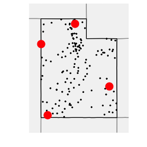

*Figure 3.1: Plot of Utah showing locations of fixed factors (in red) and all locations (in black).*

Because Logan is the fourth fixed loading location, the estimates for the fourth loading indicate the strength of the relationship of each location’s temperatures to Logan’s temperatures, after accounting for linear and seasonal processes. A higher value of the loading estimates greater similarity. Thus, the next code chunks and plots show the posterior mean estimate of Factor 4 (the common temperature behavior among those locations that have higher loading values), and a map of the predicted loading values on a grid across Utah. This map shows that locations in the northeast have higher loading values and thus will have temperature measurements that behave similarly to that of the fourth factor.

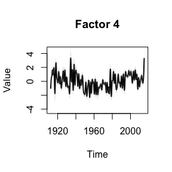

```r
plot_factor(bstfa.output,
            together=FALSE,
            include.legend=FALSE,
            factor=4,
            type='mean')
```

```
#> replace the existing one.
```

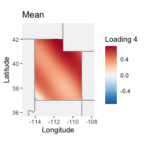

```r
map_spatial_param(bstfa.output,
         parameter='loading',
         loading=4,
         yearscale=TRUE,
         type='mean',
         map=TRUE,
         state=TRUE,
         location='utah',
         fine=100)
```

## 3.2 Basis Function Details

The choice of basis functions is assigned using the `spatial.style` and `load.style` arguments. The `spatial.style` argument controls which basis functions to use for the linear and seasonal components ($\mathbf{B_\beta}$ and each $\mathbf{B}_{\xi_j}$) while the `load.style` argument controls the basis functions for the factor loadings ($\mathbf{QS}$). The number of bases for the linear and seasonal components is specified with the argument `n.spatial.bases` while the loadings use the argument `n.load.bases`. The values given to `spatial.style` and `load.style` need not be the same, nor do `n.spatial.bases` and `n.load.bases`. The default value for both style arguments is `'fourier'`. The only basis functions used for the temporal factors themselves are Fourier bases.

### 3.2.1 Fourier

When using Fourier bases, the user needs to specify number of bases and the spatial frequency in both the longitude and latitude directions. As demonstrated in Section 2.2, the function `plot_fourier_bases` can help the user visualize Fourier bases and choose the appropriate amount of bases and frequencies. After exploratory analysis methods (demonstrated in Section 3.2.4), it seems that assigning `freq.lon` and `freq.lat` values of 40 and 30 respectively and setting `n.spatial.bases` and `n.load.bases` equal to 8 and 6, respectively, works well for the Utah data set.

The user should also consider the frequency (`freq.temp`) and number of bases (`n.temp.bases`) for the temporal factors, which always use Fourier bases. The default values (see Table 2.5) tend to work well, but increasing the number of bases can create a finer estimate at the cost of reduced computational speed.

```r
BSTFA(ymat=utahDataList$TemperatureVals,
      dates=utahDataList$Dates,
      coords=utahDataList$Coords,
      spatial.style='fourier',
      load.style='fourier',
      n.spatial.bases=8,
      n.load.bases=6,
      freq.lon=40,
      freq.lat=30,
      n.temp.bases=floor(nrow(utahDataList$TemperatureVals)/10),
      freq.temp=nrow(utahDataList$TemperatureVals))
```

### 3.2.2 Bisquare

As described in Table 2.5, multiple arguments to `BSTFA` and `BSTFAfull` are used only for bisquare bases. The argument given to `spatial.style` or `load.style` to use these basis functions is `'grid'`. The `knot.levels` argument indicates how many resolutions of knots to create, where the $r^{th}$ resolution uses $2^{2r}$ bases distributed evenly in a square grid across the coordinates of the data. Setting `plot.knots=TRUE` outputs a plot of knots in all resolutions.

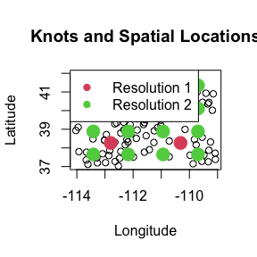

```r
bstfa.plot_knots = BSTFA(ymat=utahDataList$TemperatureVals,
                         dates=utahDataList$Dates,
                         coords=utahDataList$Coords,
                         spatial.style='grid',
                         load.style='grid',
                         knot.levels=2,
                         plot.knots=TRUE,
                         verbose=FALSE,
                         iters=10)
```

The user can specify custom knot locations with the `premade.knots` argument. This argument takes a list of coordinates containing pre-specified knots. The number of elements in the list represents the number of resolutions. Each element of the list should have the same number of columns as `coords`. Below is an example where the first resolution matches the default, but the second uses a $3 \times 3$ grid of knots rather than the default $4 \times 4$.

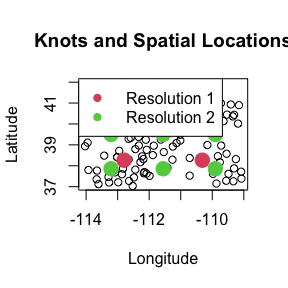

```r
knots=list()
max.lon = max(utahDataList$Coords[,1])
min.lon = min(utahDataList$Coords[,1])
max.lat = max(utahDataList$Coords[,2])
min.lat = min(utahDataList$Coords[,2])
range.lon = max.lon-min.lon
range.lat = max.lat-min.lat
knots[[1]] = expand.grid(c(min.lon+(range.lon/4), min.lon+3*(range.lon/4)),
            c(min.lat+(range.lat/4), min.lat+3*(range.lat/4)))
knots[[2]] = expand.grid(c(min.lon+(range.lon/6),
                           min.lon+(range.lon/2),
                           min.lon+5*(range.lon/6)),
                         c(min.lat+(range.lat/6),
                           min.lat+(range.lat/2),
                           min.lat+5*(range.lat/6)))
bstfa.custom_knots = BSTFA(ymat=utahDataList$TemperatureVals,
                           dates=utahDataList$Dates,
                           coords=utahDataList$Coords,
                           spatial.style='grid',
                           load.style='grid',
                           knot.levels=2,
                           plot.knots=TRUE,
                           premade.knots=knots,
                           verbose=FALSE,
                           iters=10)
```

### 3.2.3 Thin-plate splines

The argument given to `spatial.style` and `load.style` to use these basis functions is `'tps'`. The function `basis.tps` from the `npreg` package is used to create the thin-plate spline bases. The knots used to create the bases are on a square grid; thus, the number of bases is equal to `floor(sqrt(n.spatial.bases))^2` and `floor(sqrt(n.load.bases))^2`. So, even if the values 8 and 10 are given to `n.spatial.bases` and `n.load.bases` as shown in the code below, the number of bases used in the model will be 4 and 9.

```r
BSTFA(ymat=utahDataList$TemperatureVals,
      dates=utahDataList$Dates,
      coords=utahDataList$Coords,
      spatial.style='tps',
      load.style='tps',
      n.spatial.bases=8,
      n.load.bases=10)
```

### 3.2.4 Choosing Basis Functions

There are few ways to decide which spatial basis functions to use for your data. First, diagnostics such as the Watanabe-Akaike Information Criterion (WAIC) and Leave-One-Out Cross-Validation (LOO-CV) can help the user compare model fits (Vehtari et al., 2017). These can be computed using the `waic` and `loo` functions from the `loo` package. These functions require a matrix of log-likelihood values, which can be generated using the function `computeLogLik` from the `BSTFA` package, supplying as argument the output from `BSTFA` or `BSTFAfull`.

```r
loglik = computeLogLik(bstfa.output,
                       verbose=FALSE)
loo::waic(loglik)
loo::loo(loglik)
```

Table 3.1 compares the WAIC and LOO-CV for 12 different model fits on the Utah data. In each instance, the number of spatial bases is the same for both the linear/seasonal components and the factor analysis component - that is, `n.spatial.bases = n.load.bases`. The number of temporal bases is the `n.temp.bases` argument; 126 is the default for the Utah data (10% of $T$).

*Table 3.1: Summary of model performance with different basis functions.*

| Type | # of spatial bases | # of temporal bases | LOO-CV | WAIC |
| --- | --- | --- | --- | --- |
| Fourier | 8 | 126 | 202.7 | 195.8 |
| Fourier | 16 | 126 | 203.2 | 195.4 |
| Bisquare | 4 (1-level) | 126 | 203.4 | 195.4 |
| Bisquare | 20 (2-levels) | 126 | 203.6 | 195.3 |
| TPS | 9 | 126 | $\textbf{202.6}$ | 195.7 |
| TPS | 16 | 126 | 203.2 | 195.6 |
| Fourier | 8 | 200 | 204.6 | 191.6 |
| Fourier | 16 | 200 | 205.7 | $\textbf{191.4}$ |
| Bisquare | 4 (1-level) | 200 | 204.7 | 191.6 |
| Bisquare | 20 (2-levels) | 200 | 203.9 | 191.9 |
| TPS | 9 | 200 | 205.2 | 191.7 |
| TPS | 16 | 200 | 204.8 | 191.8 |

Notice that in this case, the choice of spatial basis function does not matter much, while increasing the number of temporal bases from 126 to 200 leads to a reduction in WAIC, indicating better model fit. However, increasing the number of temporal bases reduces computational efficiency (in this instance, moving from 126 to 200 temporal bases added about 0.2 seconds to each iteration).

In addition to model diagnostics, it’s also important to visually assess estimates using the different basis functions and other settings. For instance, this can be done by fitting a model with each basis function and estimating the linear slope using `map_spatial_param`, as demonstrated in Section 1.3. The row of plots below show three estimates of the second loading (based on the “East” factor for fixed loading Moab, Utah) when the loadings are fit with Fourier bases (using default values for frequency), bisquare bases, and thin-plate spline bases. The estimates for the different basis functions look quite different; this is partly because the estimated associated factors are different.

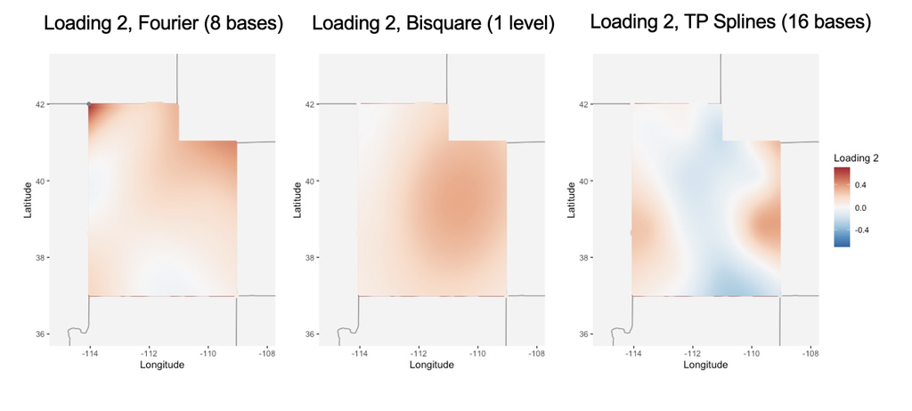

## 3.3 Assessing MCMC Convergence

The `BSTFA` package has built-in helper functions for assessing convergence. They use the fact that all matrices of parameter draws are MCMC objects from the `coda` package. To look at trace plots, you can use the `plot_trace` function. This function takes as input your `BSTFA` or `BSTFAfull` object, a string value `parameter` indicating which parameter to view (corresponds directly to what the parameter is called in the `BSTFA` list output), and `param.range` which accepts a numeric vector indicating which of these parameters you want to view.

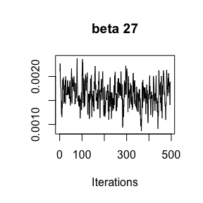

```r
plot_trace(bstfa.output,
           parameter='beta',
           param.range=c(27),
           density=FALSE)
```

The other available helper function is `convergence_diag`. This function takes as input the `BSTFA` or `BSTFAfull` function output and returns the effective sample size or Geweke diagnostic (indicated by `type='eSS'` or `type='geweke'`) for all parameters above a given cutoff (indicated by `cutoff`). For instance, the function below will return all parameters with an effective sample size below 100.

```r
convergence_diag(bstfa.output,
                  type='eSS',
                  cutoff = 100)
```

# 4 Appendices

## 4.1 Computation Notes

Below are specific notes about computation not explicitly mentioned in the vignette:

- The values for `n.spatial.bases`, `n.load.bases` and `n.temp.bases` need to be even numbers. If they are not, the function will add 1 to the supplied value.
- To help with convergence of the residual factor analysis component, the sampler waits to sample $\mathbf{F}$ and $\mathbf{\Lambda}$ until $\textit{min(floor(burn/2), 500)}$. That is why, for example, the `compute_summary` function divides computation time into “Pre-Factor Analysis” and “Post-Factor Analysis”.

## References

Berrett, C., Christensen, W. F., Sain, S. R., et al. (2020). Modeling sea-level processes on the u.s. Atlantic coast. *Environmetrics*, *31*(e2609). https://doi.org/10.1002/env.2609

Cressie, Noel, & Johannesson, Gardar. (2008). Fixed rank kriging for very large spatial data sets. *Journal of the Royal Statistical Society: Series B (Statistical Methodology)*, *70*(1), 209–226.

Cressie, N., Sainsbury-Dale, M., & Zammit-Mangion, A. (2022). Basis-function models in spatial statistics. *Annu. Rev. Stat. Appl.*, *9*. https://doi.org/10.1146/annurev-statistics-040120-020733

Nychka, Douglas W. (2000). Spatial-process estimates as smoothers. *Smoothing and Regression: Approaches, Computation, and Application*, *329*, 393.

Paciorek, Christopher J. (2007). Bayesian smoothing with gaussian processes using fourier basis functions in the spectralGP package. *Journal of Statistical Software*.

Pebesma, Edzer. (2018). Simple Features for R: Standardized Support for Spatial Vector Data. *The R Journal*, *10*(1), 439–446. https://doi.org/10.32614/RJ-2018-009

Plummer, Martyn, Best, Nicky, Cowles, Kate, & Vines, Karen. (2006). CODA: Convergence diagnosis and output analysis for MCMC. *R News*, *6*(1), 7–11. https://journal.r-project.org/archive/

Rencher, Alvin C., & Christensen, William. (2012). *Methods of multivariate analysis, third edition*. Wiley.

Vehtari, Aki, Gelman, Andrew, & Gabry, Jonah. (2017). Practical bayesian model evaluation using leave-one-out cross-validation and WAIC. *Statistics and Computing*, *27*, 1413–1432. https://doi.org/10.1007/s11222-016-9696-4

Wikle, Christopher. (2002). Spatial modeling of count data: A case study in modelling breeding bird survey data on large spatial domains. In Andrew Lawson & David Denison (Eds.), *Spatial cluster modelling* (pp. 199–209). Chapman & Hall.

Wood, Simon N. (2017). *Generalized additive models: An introduction with r*. chapman; hall/CRC.